# Milestone3_HeartDiseasePrediction

Project:-How Can Clinical and Demographic Factors Be Used to Identify Patients at Risk of Heart Disease? Milestone 3 – Initial Results, Code Structure, and Model Evaluation Student:- Kaishiv Joshi Course:- CIND 820 DAH – Big Data Analytics P2026 Dataset:- Framingham Heart Study Dataset Instructor: Tamer Abdou, PhD Department: Toronto Metropolitan University Submission Date: July 06, 2026

Objective:- The objective of this notebook is to develop an end-to-end machine learning pipeline for predicting the 10-year risk of coronary heart disease using demographic and clinical variables. This notebook demonstrates data preprocessing, exploratory data analysis, feature engineering, model development, evaluation, and interpretation.

```python
import warnings
warnings.filterwarnings("ignore")

import numpy as np
import pandas as pd

import matplotlib.pyplot as plt
import seaborn as sns

from scipy import stats

from sklearn.model_selection import train_test_split

from sklearn.impute import SimpleImputer

from sklearn.preprocessing import StandardScaler

from sklearn.feature_selection import RFE

from sklearn.linear_model import LogisticRegression

from sklearn.ensemble import RandomForestClassifier

from sklearn.metrics import (
    accuracy_score,
    precision_score,
    recall_score,
    f1_score,
    roc_auc_score,
    confusion_matrix,
    classification_report,
    roc_curve
)

from imblearn.over_sampling import SMOTE

import shap

print("Libraries imported successfully.")
```

```
Libraries imported successfully.
```

Why these libraries?

- Pandas and NumPy are used for data manipulation.
- Matplotlib and Seaborn are used for visualization.
- SciPy is used for statistical analysis.
- Scikit-learn provides preprocessing, feature selection, machine learning models, and evaluation metrics.
- SMOTE is used to address class imbalance.
- SHAP is used to explain feature importance in the final model.

Load Dataset

```python
df = pd.read_csv("framingham.csv")

print("Dataset Loaded Successfully")
df.head()
```

```
Dataset Loaded Successfully
```

|  | male | age | education | currentSmoker | cigsPerDay | BPMeds | prevalentStroke | prevalentHyp | diabetes | totChol | sysBP | diaBP | BMI | heartRate | glucose | TenYearCHD |
| --- | --- | --- | --- | --- | --- | --- | --- | --- | --- | --- | --- | --- | --- | --- | --- | --- |
| 0 | 1 | 39 | 4.0 | 0 | 0.0 | 0.0 | 0 | 0 | 0 | 195.0 | 106.0 | 70.0 | 26.97 | 80.0 | 77.0 | 0 |
| 1 | 0 | 46 | 2.0 | 0 | 0.0 | 0.0 | 0 | 0 | 0 | 250.0 | 121.0 | 81.0 | 28.73 | 95.0 | 76.0 | 0 |
| 2 | 1 | 48 | 1.0 | 1 | 20.0 | 0.0 | 0 | 0 | 0 | 245.0 | 127.5 | 80.0 | 25.34 | 75.0 | 70.0 | 0 |
| 3 | 0 | 61 | 3.0 | 1 | 30.0 | 0.0 | 0 | 1 | 0 | 225.0 | 150.0 | 95.0 | 28.58 | 65.0 | 103.0 | 1 |
| 4 | 0 | 46 | 3.0 | 1 | 23.0 | 0.0 | 0 | 0 | 0 | 285.0 | 130.0 | 84.0 | 23.10 | 85.0 | 85.0 | 0 |

```python
print("Shape of Dataset")
print(df.shape)

print("\n")

print("Column Names")
print(df.columns)

print("\n")

print("Data Types")
print(df.dtypes)
```

```
Shape of Dataset
(4240, 16)


Column Names
Index(['male', 'age', 'education', 'currentSmoker', 'cigsPerDay', 'BPMeds',
       'prevalentStroke', 'prevalentHyp', 'diabetes', 'totChol', 'sysBP',
       'diaBP', 'BMI', 'heartRate', 'glucose', 'TenYearCHD'],
      dtype='object')


Data Types
male                 int64
age                  int64
education          float64
currentSmoker        int64
cigsPerDay         float64
BPMeds             float64
prevalentStroke      int64
prevalentHyp         int64
diabetes             int64
totChol            float64
sysBP              float64
diaBP              float64
BMI                float64
heartRate          float64
glucose            float64
TenYearCHD           int64
dtype: object
```

## Dataset Description

The Framingham Heart Study dataset contains demographic, behavioural, and clinical measurements collected from adult participants.

Each row represents one patient.

The target variable is **TenYearCHD**, which indicates whether the individual developed coronary heart disease within ten years.

This dataset will be used to build a supervised machine learning classification model.

# Step 1: Initial Data Exploration

Before building a machine learning model, it is important to understand the dataset. This step provides an overview of the variables, data types, summary statistics, and potential data quality issues.

```python
df.describe().T
```

|  | count | mean | std | min | 25% | 50% | 75% | max |
| --- | --- | --- | --- | --- | --- | --- | --- | --- |
| male | 4240.0 | 0.429245 | 0.495027 | 0.00 | 0.00 | 0.0 | 1.00 | 1.0 |
| age | 4240.0 | 49.580189 | 8.572942 | 32.00 | 42.00 | 49.0 | 56.00 | 70.0 |
| education | 4135.0 | 1.979444 | 1.019791 | 1.00 | 1.00 | 2.0 | 3.00 | 4.0 |
| currentSmoker | 4240.0 | 0.494104 | 0.500024 | 0.00 | 0.00 | 0.0 | 1.00 | 1.0 |
| cigsPerDay | 4211.0 | 9.005937 | 11.922462 | 0.00 | 0.00 | 0.0 | 20.00 | 70.0 |
| BPMeds | 4187.0 | 0.029615 | 0.169544 | 0.00 | 0.00 | 0.0 | 0.00 | 1.0 |
| prevalentStroke | 4240.0 | 0.005896 | 0.076569 | 0.00 | 0.00 | 0.0 | 0.00 | 1.0 |
| prevalentHyp | 4240.0 | 0.310613 | 0.462799 | 0.00 | 0.00 | 0.0 | 1.00 | 1.0 |
| diabetes | 4240.0 | 0.025708 | 0.158280 | 0.00 | 0.00 | 0.0 | 0.00 | 1.0 |
| totChol | 4190.0 | 236.699523 | 44.591284 | 107.00 | 206.00 | 234.0 | 263.00 | 696.0 |
| sysBP | 4240.0 | 132.354599 | 22.033300 | 83.50 | 117.00 | 128.0 | 144.00 | 295.0 |
| diaBP | 4240.0 | 82.897759 | 11.910394 | 48.00 | 75.00 | 82.0 | 90.00 | 142.5 |
| BMI | 4221.0 | 25.800801 | 4.079840 | 15.54 | 23.07 | 25.4 | 28.04 | 56.8 |
| heartRate | 4239.0 | 75.878981 | 12.025348 | 44.00 | 68.00 | 75.0 | 83.00 | 143.0 |
| glucose | 3852.0 | 81.963655 | 23.954335 | 40.00 | 71.00 | 78.0 | 87.00 | 394.0 |
| TenYearCHD | 4240.0 | 0.151887 | 0.358953 | 0.00 | 0.00 | 0.0 | 0.00 | 1.0 |

## Missing Value Analysis

Missing values can reduce model performance if they are not handled correctly. This step identifies variables with incomplete observations.

```python
missing = df.isnull().sum()

missing_percent = (missing / len(df)) * 100

missing_table = pd.DataFrame({
    "Missing Values": missing,
    "Percentage": missing_percent
})

missing_table.sort_values(by="Missing Values", ascending=False)
```

|  | Missing Values | Percentage |
| --- | --- | --- |
| glucose | 388 | 9.150943 |
| education | 105 | 2.476415 |
| BPMeds | 53 | 1.250000 |
| totChol | 50 | 1.179245 |
| cigsPerDay | 29 | 0.683962 |
| BMI | 19 | 0.448113 |
| heartRate | 1 | 0.023585 |
| male | 0 | 0.000000 |
| prevalentHyp | 0 | 0.000000 |
| prevalentStroke | 0 | 0.000000 |
| age | 0 | 0.000000 |
| currentSmoker | 0 | 0.000000 |
| diaBP | 0 | 0.000000 |
| sysBP | 0 | 0.000000 |
| diabetes | 0 | 0.000000 |
| TenYearCHD | 0 | 0.000000 |

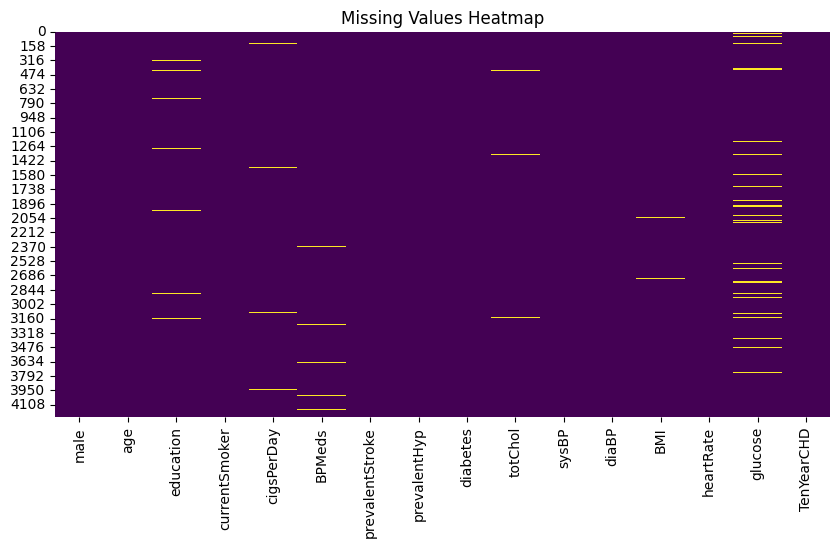

```python
plt.figure(figsize=(10,5))

sns.heatmap(df.isnull(),
            cbar=False,
            cmap="viridis")

plt.title("Missing Values Heatmap")

plt.show()
```

## Duplicate Records

Duplicate observations may bias the analysis and therefore should be identified before model development.

```python
duplicates = df.duplicated().sum()

print("Duplicate Rows :", duplicates)
```

```
Duplicate Rows : 0
```

```python
df.info()
```

```
<class 'pandas.core.frame.DataFrame'>
RangeIndex: 4240 entries, 0 to 4239
Data columns (total 16 columns):
 #   Column           Non-Null Count  Dtype
---  ------           --------------  -----
 0   male             4240 non-null   int64
 1   age              4240 non-null   int64
 2   education        4135 non-null   float64
 3   currentSmoker    4240 non-null   int64
 4   cigsPerDay       4211 non-null   float64
 5   BPMeds           4187 non-null   float64
 6   prevalentStroke  4240 non-null   int64
 7   prevalentHyp     4240 non-null   int64
 8   diabetes         4240 non-null   int64
 9   totChol          4190 non-null   float64
 10  sysBP            4240 non-null   float64
 11  diaBP            4240 non-null   float64
 12  BMI              4221 non-null   float64
 13  heartRate        4239 non-null   float64
 14  glucose          3852 non-null   float64
 15  TenYearCHD       4240 non-null   int64
dtypes: float64(9), int64(7)
memory usage: 530.1 KB
```

## Target Variable Distribution

The target variable (TenYearCHD) represents whether a patient developed coronary heart disease within ten years. Understanding its distribution helps identify class imbalance.

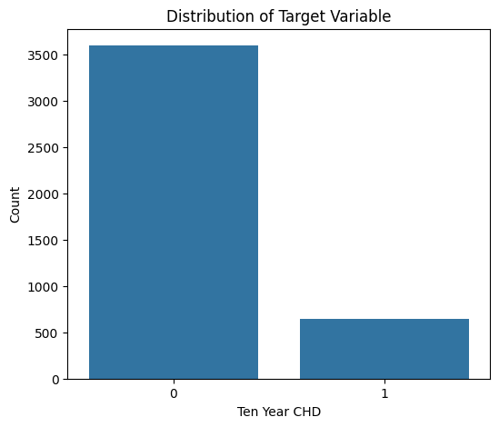

```python
plt.figure(figsize=(6,5))

sns.countplot(
    data=df,
    x="TenYearCHD"
)

plt.title("Distribution of Target Variable")

plt.xlabel("Ten Year CHD")

plt.ylabel("Count")

plt.show()
```

```python
target_counts = df["TenYearCHD"].value_counts()

target_percent = df["TenYearCHD"].value_counts(normalize=True) * 100

print(target_counts)

print()

print(target_percent)
```

```
TenYearCHD
0    3596
1     644
Name: count, dtype: int64

TenYearCHD
0    84.811321
1    15.188679
Name: proportion, dtype: float64
```

### Interpretation

The target variable is imbalanced, with substantially more patients who did not develop coronary heart disease than patients who did. Such imbalance may bias machine learning models toward the majority class. Therefore, Synthetic Minority Over-sampling Technique (SMOTE) will later be applied only to the training dataset to improve the model's ability to identify high-risk patients while avoiding information leakage.

```python
for col in df.columns:
    print("="*50)
    print(col)
    print(df[col].unique())
```

```
==================================================
male
[1 0]
==================================================
age
[39 46 48 61 43 63 45 52 50 41 38 42 44 47 60 35 36 59 54 37 56 53 49 65
 51 62 40 67 57 66 64 55 58 34 68 33 70 32 69]
==================================================
education
[ 4.  2.  1.  3. nan]
==================================================
currentSmoker
[0 1]
==================================================
cigsPerDay
[ 0. 20. 30. 23. 15.  9. 10.  5. 35. 43.  1. 40.  3.  2. nan 12.  4. 18.
 25. 60. 14. 45.  8. 50. 13. 11.  7.  6. 38. 29. 17. 16. 19. 70.]
==================================================
BPMeds
[ 0.  1. nan]
==================================================
prevalentStroke
[0 1]
==================================================
prevalentHyp
[0 1]
==================================================
diabetes
[0 1]
==================================================
totChol
[195. 250. 245. 225. 285. 228. 205. 313. 260. 254. 247. 294. 332. 226.
 221. 232. 291. 190. 185. 234. 215. 270. 272. 295. 209. 175. 214. 257.
 178. 233. 180. 243. 237.  nan 311. 208. 252. 261. 179. 194. 267. 216.
 240. 266. 255. 220. 235. 212. 223. 300. 302. 248. 200. 189. 258. 202.
 213. 183. 274. 170. 210. 197. 326. 188. 256. 244. 193. 239. 296. 269.
 275. 268. 265. 173. 273. 290. 278. 264. 282. 241. 288. 222. 303. 246.
 150. 187. 286. 154. 279. 293. 259. 219. 230. 320. 312. 165. 159. 174.
 242. 301. 167. 308. 325. 229. 236. 224. 253. 464. 171. 186. 227. 249.
 176. 163. 191. 263. 196. 310. 164. 135. 238. 207. 342. 287. 182. 352.
```

[output cut: 58 more lines]

```
glucose
[ 77.  76.  70. 103.  85.  99.  78.  79.  88.  61.  64.  84.  nan  72.
  89.  65. 113.  75.  83.  66.  74.  63.  87. 225.  90.  80. 100. 215.
  98.  62.  95.  94.  55.  82.  93.  73.  45. 202.  68.  97. 104.  96.
 126. 120. 105.  71.  56.  60. 117. 102.  58.  92. 109.  86. 107.  54.
  67.  69.  57.  91. 132. 150.  59.  81. 115. 140. 112. 118. 143. 114.
 160. 110. 123. 108. 145. 122. 137. 106. 127. 205. 130. 101.  47.  53.
 216. 163. 144. 116. 121. 172. 124. 111.  40. 186. 223. 325.  44. 156.
 268.  50. 274. 292. 255. 136. 206. 131. 148. 297.  43. 173.  48. 386.
 155. 147. 170.  52. 320. 254. 394. 270. 244. 183. 142. 119. 135. 167.
 207. 129. 177. 250. 294. 166. 125. 332. 368. 348. 248. 370. 193. 191.
 256. 235. 210. 260.]
==================================================
TenYearCHD
[0 1]
```

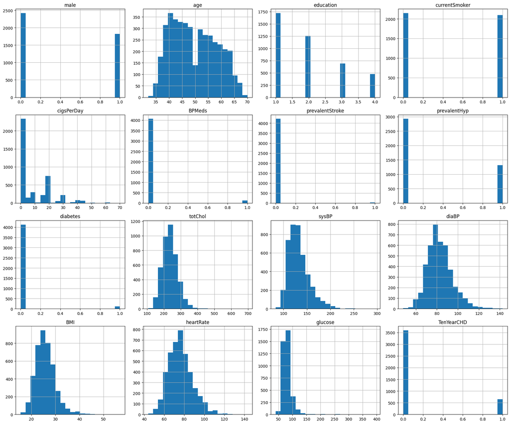

```python
numerical_columns = df.select_dtypes(include=["int64","float64"]).columns

df[numerical_columns].hist(
    figsize=(18,15),
    bins=20
)

plt.tight_layout()

plt.show()
```

# Step 2: Exploratory Data Analysis (EDA)

Exploratory Data Analysis helps identify patterns, distributions, relationships, and potential data quality issues such as outliers before model development.

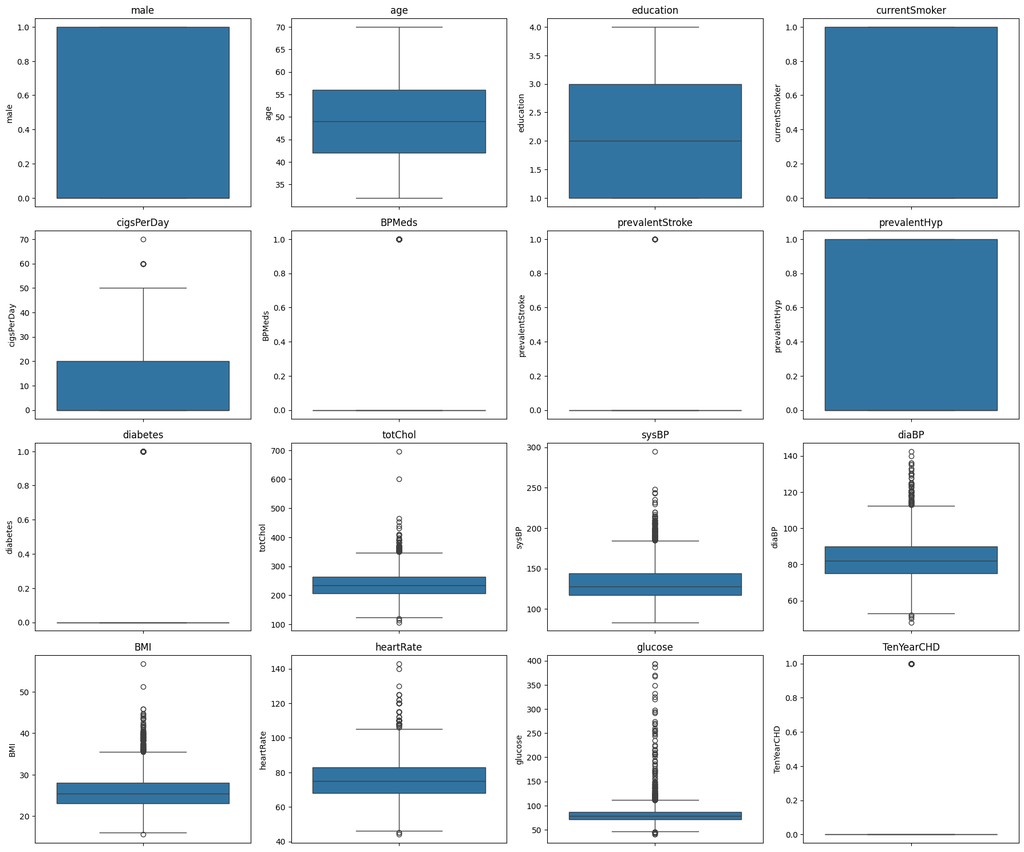

```python
plt.figure(figsize=(18,15))

for i, column in enumerate(numerical_columns):
    plt.subplot(4,4,i+1)
    sns.boxplot(y=df[column])
    plt.title(column)

plt.tight_layout()

plt.show()
```

### Interpretation of Boxplots

Several numerical variables contain outliers, particularly systolic blood pressure, diastolic blood pressure, BMI, cholesterol, glucose, and heart rate. These values may represent genuine clinical measurements rather than data entry errors. Therefore, the outliers will be retained unless they are found to be invalid, allowing the machine learning models to learn from real clinical variation.

## Correlation Analysis

A correlation heatmap is used to examine relationships between numerical variables. Highly correlated variables may indicate multicollinearity, which can affect certain machine learning algorithms such as Logistic Regression.

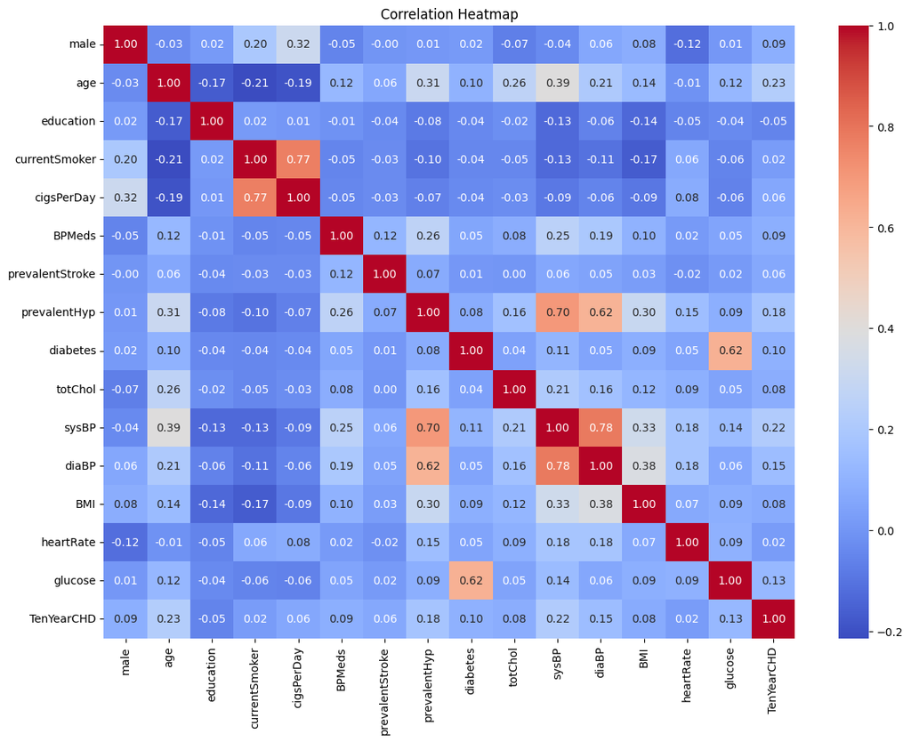

```python
plt.figure(figsize=(14,10))

corr = df.corr(numeric_only=True)

sns.heatmap(
    corr,
    cmap="coolwarm",
    annot=True,
    fmt=".2f"
)

plt.title("Correlation Heatmap")

plt.show()
```

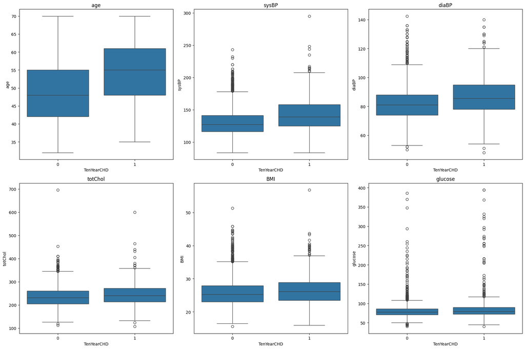

```python
important_features = [
    "age",
    "sysBP",
    "diaBP",
    "totChol",
    "BMI",
    "glucose"
]

plt.figure(figsize=(18,12))

for i, col in enumerate(important_features):
    plt.subplot(2,3,i+1)
    sns.boxplot(
        x="TenYearCHD",
        y=col,
        data=df
    )
    plt.title(col)

plt.tight_layout()

plt.show()
```

### Interpretation

Patients who developed coronary heart disease generally exhibit higher values for age, systolic blood pressure, cholesterol, BMI, and glucose compared with those who did not develop the disease. These observations suggest that these variables may contribute to heart disease prediction and should be considered during model development.

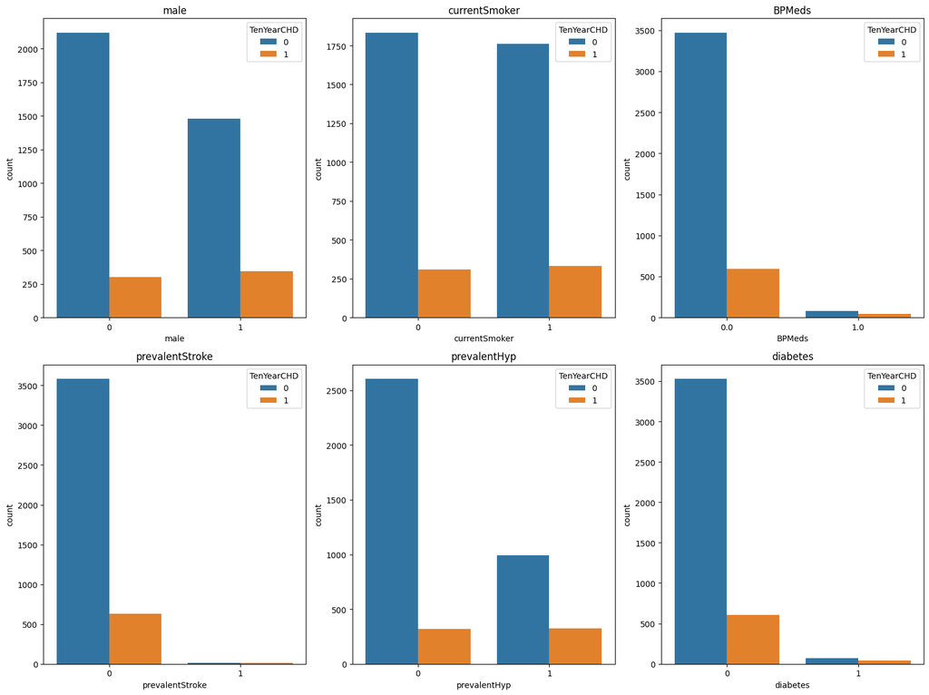

```python
categorical_columns = [
    "male",
    "currentSmoker",
    "BPMeds",
    "prevalentStroke",
    "prevalentHyp",
    "diabetes"
]

plt.figure(figsize=(16,12))

for i,col in enumerate(categorical_columns):

    plt.subplot(2,3,i+1)

    sns.countplot(
        x=col,
        hue="TenYearCHD",
        data=df
    )

    plt.title(col)

plt.tight_layout()

plt.show()
```

### Interpretation

The categorical variables indicate that hypertension, diabetes, smoking status, and the use of blood pressure medication appear to be associated with an increased frequency of coronary heart disease. These visual observations will be examined further using statistical analysis and machine learning models.

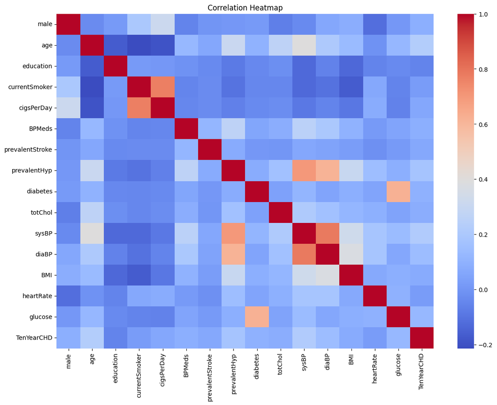

```python
import os

os.makedirs("figures", exist_ok=True)

plt.figure(figsize=(14,10))

sns.heatmap(
    corr,
    cmap="coolwarm",
    annot=False
)

plt.title("Correlation Heatmap")

plt.savefig(
    "figures/correlation_heatmap.png",
    dpi=300,
    bbox_inches="tight"
)

plt.show()
```

Separate Features and Target

# Step 3: Data Preparation for Machine Learning

Before training machine learning models, the predictor variables (features) must be separated from the target variable. The target variable (TenYearCHD) represents whether a patient developed coronary heart disease within ten years.

```python
X = df.drop("TenYearCHD", axis=1)

y = df["TenYearCHD"]

print("Feature Matrix Shape :", X.shape)
print("Target Shape :", y.shape)
```

```
Feature Matrix Shape : (4240, 15)
Target Shape : (4240,)
```

## Train-Test Split

The dataset is divided into training and testing sets before any preprocessing steps. This prevents information from the testing data from influencing model training and helps provide an unbiased estimate of model performance.

```python
X_train, X_test, y_train, y_test = train_test_split(
    X,
    y,
    test_size=0.20,
    random_state=42,
    stratify=y
)

print("Training Set :", X_train.shape)
print("Testing Set :", X_test.shape)
```

```
Training Set : (3392, 15)
Testing Set : (848, 15)
```

```python
print("Training Class Distribution")
print(y_train.value_counts(normalize=True) * 100)

print("\n")

print("Testing Class Distribution")
print(y_test.value_counts(normalize=True) * 100)
```

```
Training Class Distribution
TenYearCHD
0    84.817217
1    15.182783
Name: proportion, dtype: float64


Testing Class Distribution
TenYearCHD
0    84.787736
1    15.212264
Name: proportion, dtype: float64
```

## Missing Value Imputation

Missing values are handled after splitting the dataset. The imputer is fitted using only the training data and then applied to both the training and testing datasets. This prevents information leakage from the testing set.

```python
imputer = SimpleImputer(strategy="median")

X_train_imputed = pd.DataFrame(
    imputer.fit_transform(X_train),
    columns=X_train.columns
)

X_test_imputed = pd.DataFrame(
    imputer.transform(X_test),
    columns=X_test.columns
)

print("Missing values in training data:",
      X_train_imputed.isnull().sum().sum())

print("Missing values in testing data:",
      X_test_imputed.isnull().sum().sum())
```

```
Missing values in training data: 0
Missing values in testing data: 0
```

## Feature Scaling

Standardization is applied to numerical variables so that variables with different units and ranges contribute equally to machine learning algorithms such as Logistic Regression.

```python
scaler = StandardScaler()

X_train_scaled = scaler.fit_transform(X_train_imputed)

X_test_scaled = scaler.transform(X_test_imputed)

print("Scaling completed.")
```

```
Scaling completed.
```

Apply SMOTE (Training Data Only)

## Handling Class Imbalance

The training data is imbalanced because there are substantially fewer patients with coronary heart disease than without. SMOTE is applied only to the training data to create synthetic minority class examples and improve the model's ability to identify high-risk patients.

```python
smote = SMOTE(random_state=42)

X_train_smote, y_train_smote = smote.fit_resample(
    X_train_scaled,
    y_train
)

print("Original Training Shape")
print(X_train_scaled.shape)

print()

print("Balanced Training Shape")
print(X_train_smote.shape)
```

```
Original Training Shape
(3392, 15)

Balanced Training Shape
(5754, 15)
```

```python
print("Before SMOTE")

print(y_train.value_counts())

print("\n")

print("After SMOTE")

print(pd.Series(y_train_smote).value_counts())
```

```
Before SMOTE
TenYearCHD
0    2877
1     515
Name: count, dtype: int64


After SMOTE
TenYearCHD
0    2877
1    2877
Name: count, dtype: int64
```

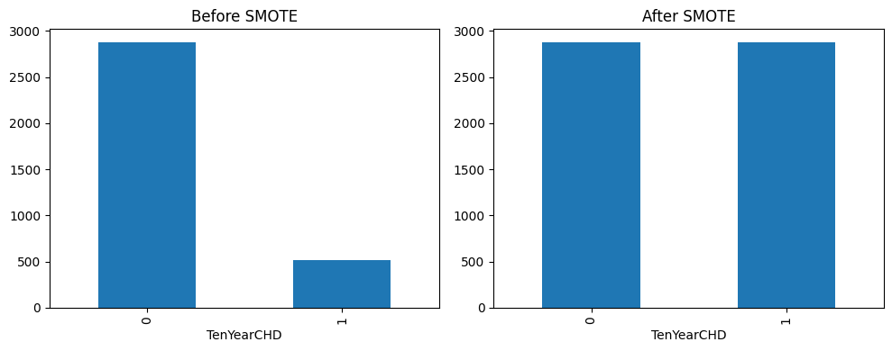

```python
fig, ax = plt.subplots(1, 2, figsize=(10, 4))

y_train.value_counts().plot(
    kind="bar",
    ax=ax[0],
    title="Before SMOTE"
)

pd.Series(y_train_smote).value_counts().plot(
    kind="bar",
    ax=ax[1],
    title="After SMOTE"
)

plt.tight_layout()

plt.show()
```

### Interpretation

The original training dataset contained considerably fewer positive coronary heart disease cases than negative cases. After applying SMOTE, both classes were equally represented in the training dataset. This balanced dataset is expected to improve the model's ability to identify patients at higher risk of coronary heart disease while reducing bias toward the majority class.

Feature Selection Using RFE

# Step 4: Feature Selection

Feature selection helps identify the most informative predictor variables while reducing unnecessary complexity. Recursive Feature Elimination (RFE) is used with Logistic Regression as the estimator to rank and select important variables.

```python
lr_rfe = LogisticRegression(max_iter=1000, random_state=42)

rfe = RFE(
    estimator=lr_rfe,
    n_features_to_select=10
)

rfe.fit(X_train_smote, y_train_smote)

selected_features = X_train.columns[rfe.support_]

print("Selected Features:")
print(selected_features)
```

```
Selected Features:
Index(['male', 'age', 'cigsPerDay', 'BPMeds', 'prevalentStroke', 'totChol',
       'sysBP', 'diaBP', 'heartRate', 'glucose'],
      dtype='object')
```

```python
feature_ranking = pd.DataFrame({
    "Feature": X_train.columns,
    "Selected": rfe.support_,
    "Ranking": rfe.ranking_
})

feature_ranking.sort_values("Ranking")
```

|  | Feature | Selected | Ranking |
| --- | --- | --- | --- |
| 0 | male | True | 1 |
| 1 | age | True | 1 |
| 5 | BPMeds | True | 1 |
| 4 | cigsPerDay | True | 1 |
| 6 | prevalentStroke | True | 1 |
| 11 | diaBP | True | 1 |
| 10 | sysBP | True | 1 |
| 9 | totChol | True | 1 |
| 14 | glucose | True | 1 |
| 13 | heartRate | True | 1 |
| 7 | prevalentHyp | False | 2 |
| 3 | currentSmoker | False | 3 |
| 2 | education | False | 4 |
| 8 | diabetes | False | 5 |
| 12 | BMI | False | 6 |

### Interpretation

Recursive Feature Elimination selected the ten most informative predictor variables based on Logistic Regression. These variables will be used to build the baseline classification model. Selecting relevant variables helps reduce model complexity while maintaining predictive performance.

```python
X_train_selected = pd.DataFrame(
    X_train_smote,
    columns=X_train.columns
)[selected_features]

X_test_selected = pd.DataFrame(
    X_test_scaled,
    columns=X_train.columns
)[selected_features]

print(X_train_selected.shape)
print(X_test_selected.shape)
```

```
(5754, 10)
(848, 10)
```

# Step 5: Baseline Model – Logistic Regression

Logistic Regression was selected as the baseline model because it is widely used in clinical prediction studies. It provides interpretable coefficients and serves as a benchmark against which more complex machine learning models can be compared.

```python
log_model = LogisticRegression(
    random_state=42,
    max_iter=1000
)

log_model.fit(
    X_train_selected,
    y_train_smote
)

print("Logistic Regression Model Trained Successfully")
```

```
Logistic Regression Model Trained Successfully
```

```python
y_pred_log = log_model.predict(X_test_selected)

y_prob_log = log_model.predict_proba(X_test_selected)[:,1]
```

```python
log_accuracy = accuracy_score(
    y_test,
    y_pred_log
)

log_precision = precision_score(
    y_test,
    y_pred_log
)

log_recall = recall_score(
    y_test,
    y_pred_log
)

log_f1 = f1_score(
    y_test,
    y_pred_log
)

log_auc = roc_auc_score(
    y_test,
    y_prob_log
)

print("Accuracy :", round(log_accuracy,3))
print("Precision:", round(log_precision,3))
print("Recall   :", round(log_recall,3))
print("F1 Score :", round(log_f1,3))
print("ROC AUC  :", round(log_auc,3))
```

```
Accuracy : 0.662
Precision: 0.244
Recall   : 0.581
F1 Score : 0.343
ROC AUC  : 0.694
```

```python
print(classification_report(
    y_test,
    y_pred_log
))
```

```
              precision    recall  f1-score   support

           0       0.90      0.68      0.77       719
           1       0.24      0.58      0.34       129

    accuracy                           0.66       848
   macro avg       0.57      0.63      0.56       848
weighted avg       0.80      0.66      0.71       848
```

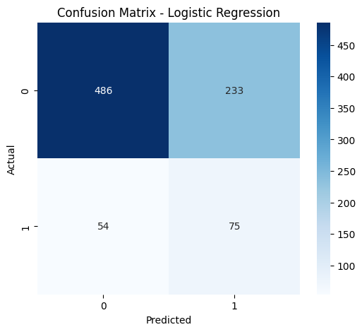

```python
cm = confusion_matrix(
    y_test,
    y_pred_log
)

plt.figure(figsize=(6,5))

sns.heatmap(
    cm,
    annot=True,
    fmt="d",
    cmap="Blues"
)

plt.xlabel("Predicted")

plt.ylabel("Actual")

plt.title("Confusion Matrix - Logistic Regression")

plt.show()
```

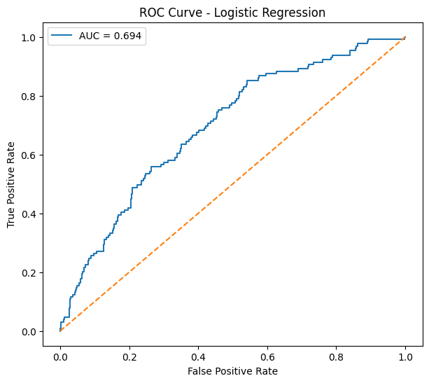

```python
fpr, tpr, thresholds = roc_curve(
    y_test,
    y_prob_log
)

plt.figure(figsize=(7,6))

plt.plot(
    fpr,
    tpr,
    label=f"AUC = {log_auc:.3f}"
)

plt.plot(
    [0,1],
    [0,1],
    linestyle="--"
)

plt.xlabel("False Positive Rate")

plt.ylabel("True Positive Rate")

plt.title("ROC Curve - Logistic Regression")

plt.legend()

plt.show()
```

### Interpretation

Logistic Regression served as the baseline classification model for predicting the ten-year risk of coronary heart disease. The model provides a transparent and interpretable benchmark against which more advanced machine learning models will be compared. The evaluation metrics indicate the model's ability to correctly classify high-risk patients while balancing precision and recall. These results establish a reference point for evaluating whether Random Forest and XGBoost provide meaningful improvements.

# Step 6: Random Forest Model

Random Forest is an ensemble machine learning algorithm that combines multiple decision trees to improve prediction accuracy and reduce overfitting. Unlike Logistic Regression, Random Forest can capture nonlinear relationships and complex interactions among predictor variables.

```python
rf_model = RandomForestClassifier(
    n_estimators=200,
    random_state=42,
    max_depth=10
)

rf_model.fit(
    X_train_selected,
    y_train_smote
)

print("Random Forest Model Trained Successfully")
```

```
Random Forest Model Trained Successfully
```

```python
y_pred_rf = rf_model.predict(
    X_test_selected
)

y_prob_rf = rf_model.predict_proba(
    X_test_selected
)[:,1]
```

```python
rf_accuracy = accuracy_score(
    y_test,
    y_pred_rf
)

rf_precision = precision_score(
    y_test,
    y_pred_rf
)

rf_recall = recall_score(
    y_test,
    y_pred_rf
)

rf_f1 = f1_score(
    y_test,
    y_pred_rf
)

rf_auc = roc_auc_score(
    y_test,
    y_prob_rf
)

print("Accuracy :", round(rf_accuracy,3))
print("Precision:", round(rf_precision,3))
print("Recall   :", round(rf_recall,3))
print("F1 Score :", round(rf_f1,3))
print("ROC AUC  :", round(rf_auc,3))
```

```
Accuracy : 0.703
Precision: 0.234
Recall   : 0.419
F1 Score : 0.3
ROC AUC  : 0.653
```

```python
print(classification_report(
    y_test,
    y_pred_rf
))
```

```
              precision    recall  f1-score   support

           0       0.88      0.75      0.81       719
           1       0.23      0.42      0.30       129

    accuracy                           0.70       848
   macro avg       0.56      0.59      0.56       848
weighted avg       0.78      0.70      0.73       848
```

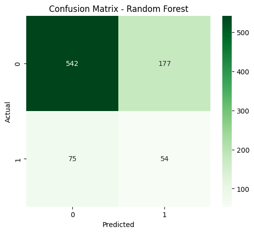

```python
cm_rf = confusion_matrix(
    y_test,
    y_pred_rf
)

plt.figure(figsize=(6,5))

sns.heatmap(
    cm_rf,
    annot=True,
    fmt="d",
    cmap="Greens"
)

plt.title("Confusion Matrix - Random Forest")

plt.xlabel("Predicted")

plt.ylabel("Actual")

plt.show()
```

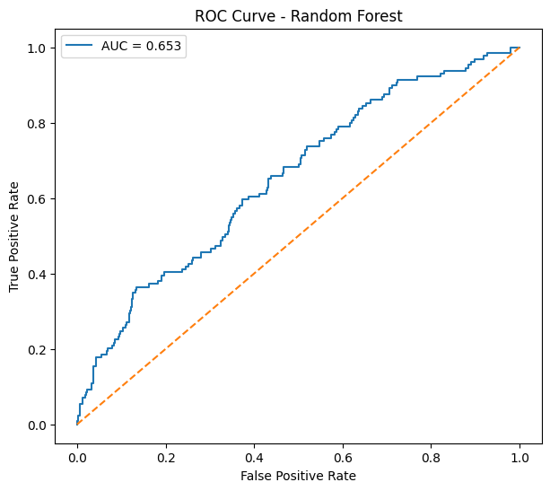

```python
fpr_rf, tpr_rf, threshold_rf = roc_curve(
    y_test,
    y_prob_rf
)

plt.figure(figsize=(7,6))

plt.plot(
    fpr_rf,
    tpr_rf,
    label=f"AUC = {rf_auc:.3f}"
)

plt.plot(
    [0,1],
    [0,1],
    linestyle="--"
)

plt.xlabel("False Positive Rate")

plt.ylabel("True Positive Rate")

plt.title("ROC Curve - Random Forest")

plt.legend()

plt.show()
```

## Random Forest Feature Importance

Random Forest estimates the relative importance of each predictor variable based on its contribution to reducing classification error across all decision trees.

```python
feature_importance = pd.DataFrame({
    "Feature": selected_features,
    "Importance": rf_model.feature_importances_
})

feature_importance = feature_importance.sort_values(
    by="Importance",
    ascending=False
)

feature_importance
```

|  | Feature | Importance |
| --- | --- | --- |
| 1 | age | 0.290089 |
| 6 | sysBP | 0.160206 |
| 7 | diaBP | 0.115962 |
| 8 | heartRate | 0.104533 |
| 5 | totChol | 0.102766 |
| 9 | glucose | 0.097029 |
| 2 | cigsPerDay | 0.077283 |
| 0 | male | 0.040103 |
| 3 | BPMeds | 0.010596 |
| 4 | prevalentStroke | 0.001433 |

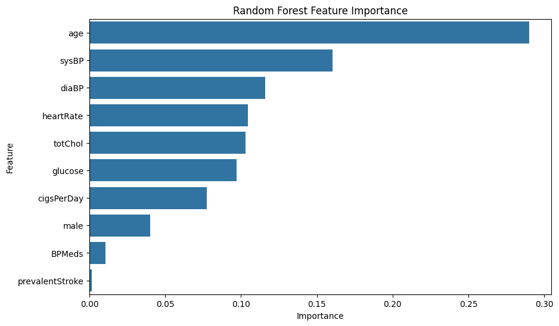

```python
plt.figure(figsize=(10,6))

sns.barplot(
    data=feature_importance,
    x="Importance",
    y="Feature"
)

plt.title("Random Forest Feature Importance")

plt.show()
```

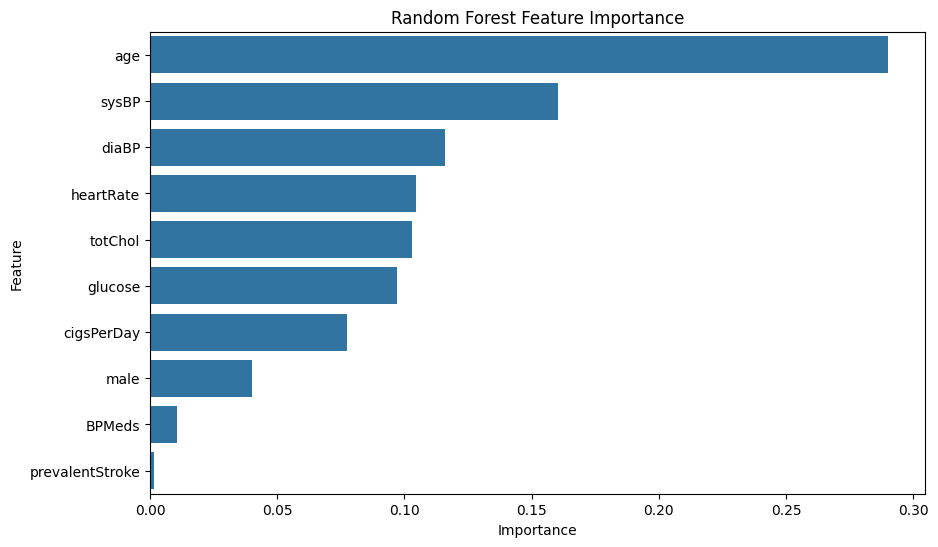

```python
plt.figure(figsize=(10,6))

sns.barplot(
    data=feature_importance,
    x="Importance",
    y="Feature"
)

plt.title("Random Forest Feature Importance")

plt.savefig(
    "figures/random_forest_feature_importance.png",
    dpi=300,
    bbox_inches="tight"
)

plt.show()
```

```python
import xgboost
```

```python
pip install xgboost
```

# Step 7: XGBoost Model

Extreme Gradient Boosting (XGBoost) is an advanced ensemble learning algorithm that builds decision trees sequentially. Each new tree attempts to correct the errors made by the previous trees, often resulting in improved predictive performance. XGBoost is widely used in healthcare analytics because of its ability to model complex nonlinear relationships while maintaining high accuracy.

```python
from xgboost import XGBClassifier
```

```python
xgb_model = XGBClassifier(
    random_state=42,
    n_estimators=200,
    learning_rate=0.05,
    max_depth=4,
    subsample=0.8,
    colsample_bytree=0.8,
    eval_metric="logloss"
)

xgb_model.fit(
    X_train_selected,
    y_train_smote
)

print("XGBoost Model Trained Successfully")
```

```
XGBoost Model Trained Successfully
```

```python
y_pred_xgb = xgb_model.predict(
    X_test_selected
)

y_prob_xgb = xgb_model.predict_proba(
    X_test_selected
)[:,1]
```

```python
xgb_accuracy = accuracy_score(
    y_test,
    y_pred_xgb
)

xgb_precision = precision_score(
    y_test,
    y_pred_xgb
)

xgb_recall = recall_score(
    y_test,
    y_pred_xgb
)

xgb_f1 = f1_score(
    y_test,
    y_pred_xgb
)

xgb_auc = roc_auc_score(
    y_test,
    y_prob_xgb
)

print("Accuracy :", round(xgb_accuracy,3))
print("Precision:", round(xgb_precision,3))
print("Recall   :", round(xgb_recall,3))
print("F1 Score :", round(xgb_f1,3))
print("ROC AUC  :", round(xgb_auc,3))
```

```
Accuracy : 0.754
Precision: 0.262
Recall   : 0.341
F1 Score : 0.296
ROC AUC  : 0.65
```

```python
print(classification_report(
    y_test,
    y_pred_xgb
))
```

```
              precision    recall  f1-score   support

           0       0.88      0.83      0.85       719
           1       0.26      0.34      0.30       129

    accuracy                           0.75       848
   macro avg       0.57      0.58      0.57       848
weighted avg       0.78      0.75      0.77       848
```

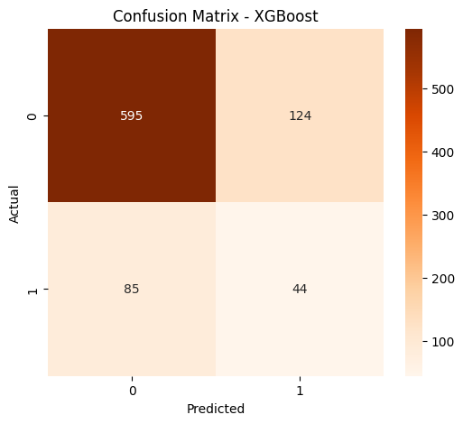

```python
cm_xgb = confusion_matrix(
    y_test,
    y_pred_xgb
)

plt.figure(figsize=(6,5))

sns.heatmap(
    cm_xgb,
    annot=True,
    fmt="d",
    cmap="Oranges"
)

plt.title("Confusion Matrix - XGBoost")

plt.xlabel("Predicted")

plt.ylabel("Actual")

plt.show()
```

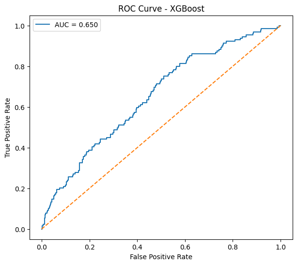

```python
fpr_xgb, tpr_xgb, threshold_xgb = roc_curve(
    y_test,
    y_prob_xgb
)

plt.figure(figsize=(7,6))

plt.plot(
    fpr_xgb,
    tpr_xgb,
    label=f"AUC = {xgb_auc:.3f}"
)

plt.plot(
    [0,1],
    [0,1],
    linestyle="--"
)

plt.xlabel("False Positive Rate")

plt.ylabel("True Positive Rate")

plt.title("ROC Curve - XGBoost")

plt.legend()

plt.show()
```

## XGBoost Feature Importance

XGBoost estimates the contribution of each predictor variable based on its usefulness in reducing prediction error across all boosted decision trees.

```python
xgb_importance = pd.DataFrame({
    "Feature": selected_features,
    "Importance": xgb_model.feature_importances_
})

xgb_importance = xgb_importance.sort_values(
    by="Importance",
    ascending=False
)

xgb_importance
```

|  | Feature | Importance |
| --- | --- | --- |
| 1 | age | 0.212142 |
| 0 | male | 0.139172 |
| 6 | sysBP | 0.106868 |
| 2 | cigsPerDay | 0.106450 |
| 8 | heartRate | 0.102340 |
| 3 | BPMeds | 0.093790 |
| 9 | glucose | 0.085711 |
| 4 | prevalentStroke | 0.051945 |
| 5 | totChol | 0.051330 |
| 7 | diaBP | 0.050251 |

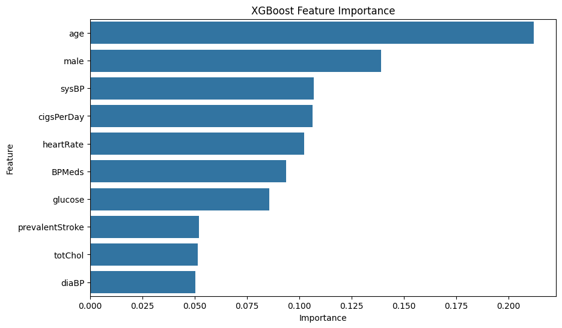

```python
plt.figure(figsize=(10,6))

sns.barplot(
    data=xgb_importance,
    x="Importance",
    y="Feature"
)

plt.title("XGBoost Feature Importance")

plt.show()
```

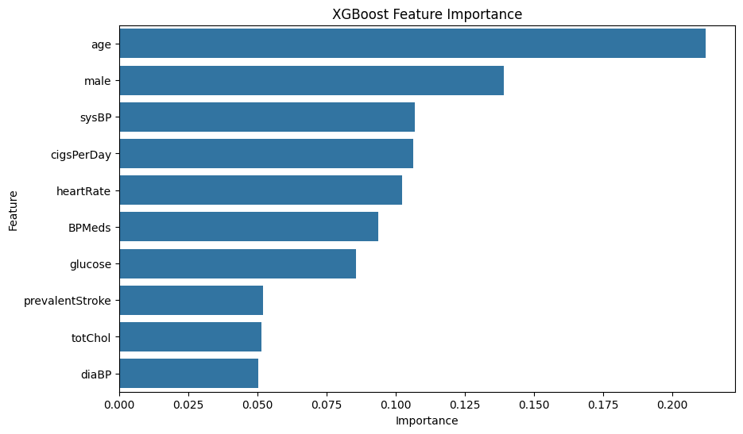

```python
plt.figure(figsize=(10,6))

sns.barplot(
    data=xgb_importance,
    x="Importance",
    y="Feature"
)

plt.title("XGBoost Feature Importance")

plt.savefig(
    "figures/xgboost_feature_importance.png",
    dpi=300,
    bbox_inches="tight"
)

plt.show()
```